# Final Project

3/13/2023

## Final Project

My research questions focused on educational achievement and educational funding. I looked at how both of those variables changed over time, and how they differed scross states within the US.

## Data

The data used for this project come from the KIDS COUNT Study, which is conducted by the Annie E. Casey Foundation (https://datacenter.kidscount.org/). Data is collected at both the national level and the state level within the US. The KIDS COUNT project contains data related to a number of different aspects of child development and well-being, including education, health, risky behavior, and family/community relationships.

For my project, I looked at 8th grade achievement in math and science, as well as per-student educational spending. Data were available at the state and national level for all variables. Funding data was collected every year, and achievement data were collected about every two years.

## Visualization 1: Maps

Goal: Create maps showing state-level differences in educational achievement

Issues & Improvements:

- Loading times
- Unnecessary message printing
- Visibility w/ faceting

Solution:

- Statebins package
- Using dashboard to organize rather than faceting

## Map Plot

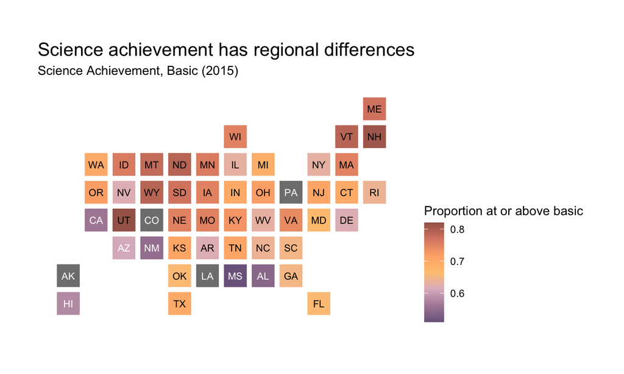

## Map Plot Code

```r
state_plot <- statebins(science_2015 %>% filter(AchievementLevel == "At or above basic"),
state_col = "NAME",
value_col = "Data") +
  scale_fill_gradientn(colors=met.brewer("Morgenstern")) +
  labs(title="Science Achievement, Basic (2015)") +
  theme_statebins("right")
```

## Visualization 2: State Funding

Goal: Show average per-student funding for all states in one readable plot.

Issues & Improvements:

- Readability
- Label alignment
- Sorting & Grouping

## Original Version

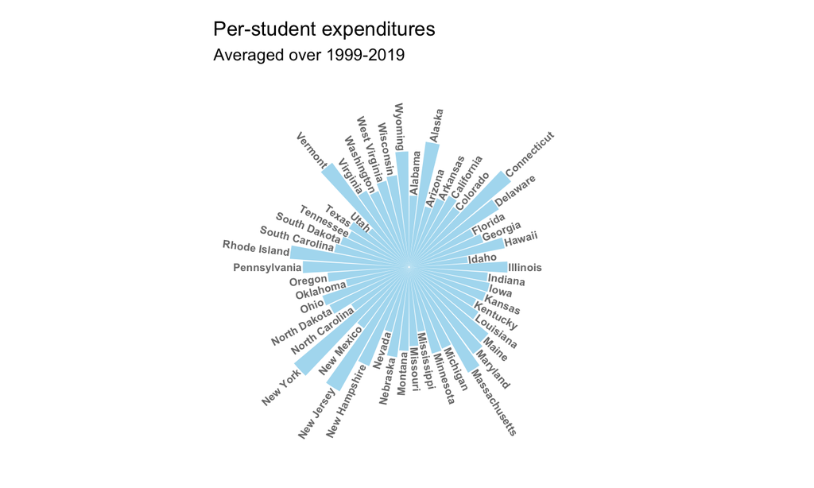

## Improved Version

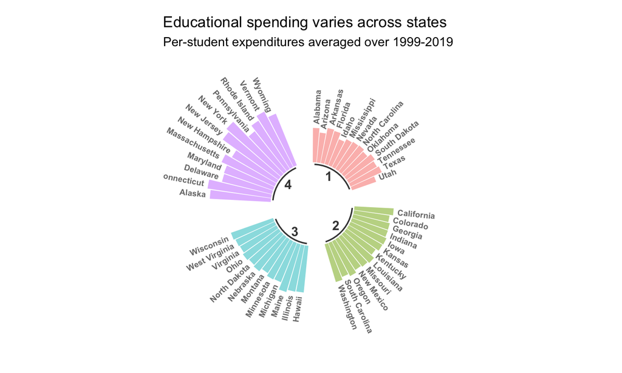